# 使用tidymodels架構建立預測模型

Yi-Ju Tseng

2020-05-14

人工智慧/機器學習/資料探勘正夯，剛好`tidymodels`套件組的[官網](https://www.tidymodels.org/)上線了，順勢介紹由`caret`套件的開發者[Max Kuhn](https://twitter.com/topepos)所帶領開發的全新建模架構`tidymodels`並完成此篇教學文章。如同套件名稱，`tidymodels`套件組的撰寫邏輯和方法與`tidyverse`套件組合相同，若熟悉`dplyr`、`ggplot`等套件應該蠻好上手

第一次使用前一樣要先安裝

```r
install.packages("tidymodels")
```

安裝後即可載入

```r
library(tidymodels)
```

載入建模過程需要的其他套件，`themis`套件是做unser sampling或over sampling前處理會用到，`vip`套件則是用在輸出隨機森林Random Forest模型中各變數的重要性。

```r
library(themis)
library(vip)
```

# 建模範例資料以及刪除遺漏值

這邊使用`mlbench`套件中的`PimaIndiansDiabetes2`資料集，該資料集的Outcome為是否有糖尿病diabetes，變數我就不一一介紹了，可輸入`?PimaIndiansDiabetes2`查看。

```r
library(mlbench)
data("PimaIndiansDiabetes2")
```

資料載入後，習慣先看一下各資料的型態跟資料筆數，可以發現有不少NA值

```r
glimpse(PimaIndiansDiabetes2)
```

```
## Rows: 768
## Columns: 9
## $ pregnant <dbl> 6, 1, 8, 1, 0, 5, 3, 10, 2, 8, 4, 10, 10, 1, 5, 7, 0, 7, 1...
## $ glucose  <dbl> 148, 85, 183, 89, 137, 116, 78, 115, 197, 125, 110, 168, 1...
## $ pressure <dbl> 72, 66, 64, 66, 40, 74, 50, NA, 70, 96, 92, 74, 80, 60, 72...
## $ triceps  <dbl> 35, 29, NA, 23, 35, NA, 32, NA, 45, NA, NA, NA, NA, 23, 19...
## $ insulin  <dbl> NA, NA, NA, 94, 168, NA, 88, NA, 543, NA, NA, NA, NA, 846,...
## $ mass     <dbl> 33.6, 26.6, 23.3, 28.1, 43.1, 25.6, 31.0, 35.3, 30.5, NA, ...
## $ pedigree <dbl> 0.627, 0.351, 0.672, 0.167, 2.288, 0.201, 0.248, 0.134, 0....
## $ age      <dbl> 50, 31, 32, 21, 33, 30, 26, 29, 53, 54, 30, 34, 57, 59, 51...
## $ diabetes <fct> pos, neg, pos, neg, pos, neg, pos, neg, pos, pos, neg, pos...
```

在刪除不全的資料前，先看一下有糖尿病diabetes跟沒有糖尿病的人數與比例，大概是65:35，有些不平均不過還行。

```r
PimaIndiansDiabetes2 %>%
  count(diabetes) %>%
  mutate(prop = n/sum(n))
```

```
## # A tibble: 2 x 3
##   diabetes     n  prop
##   <fct>    <int> <dbl>
## 1 neg        500 0.651
## 2 pos        268 0.349
```

通常有NA的資料不太會留，因為某些演算法不能用有NA的資料建模，雖然`tidymodels`有其他方法可以將NA資料去除，但為了後續基礎統計方便，如果要刪NA我還是習慣先全數刪除。

```r
PimaIndiansDiabetes2<-
  PimaIndiansDiabetes2 %>%
  filter(complete.cases(PimaIndiansDiabetes2))
```

刪除NA後資料筆數有些微改變，但大概還是6x:3x的比例

```r
PimaIndiansDiabetes2 %>%
  count(diabetes) %>%
  mutate(prop = n/sum(n))
```

```
## # A tibble: 2 x 3
##   diabetes     n  prop
##   <fct>    <int> <dbl>
## 1 neg        262 0.668
## 2 pos        130 0.332
```

完成初步資料排除後，就可以開始基礎統計分析與建模，基礎統計分析可看其他文章，這篇著重在建模。

# 訓練/調整與驗證模型效能策略

JAMA在2019年刊登一篇有趣的文章，名稱為How to Read Articles That Use Machine Learning - Users’ Guides to the Medical Literature [下載](https://jamanetwork.com/journals/jama/fullarticle/2754798)，內文中有提到在機器學習時代，如何建立與預測模型，跟之前又有什麼不同，並用下圖來解釋差異

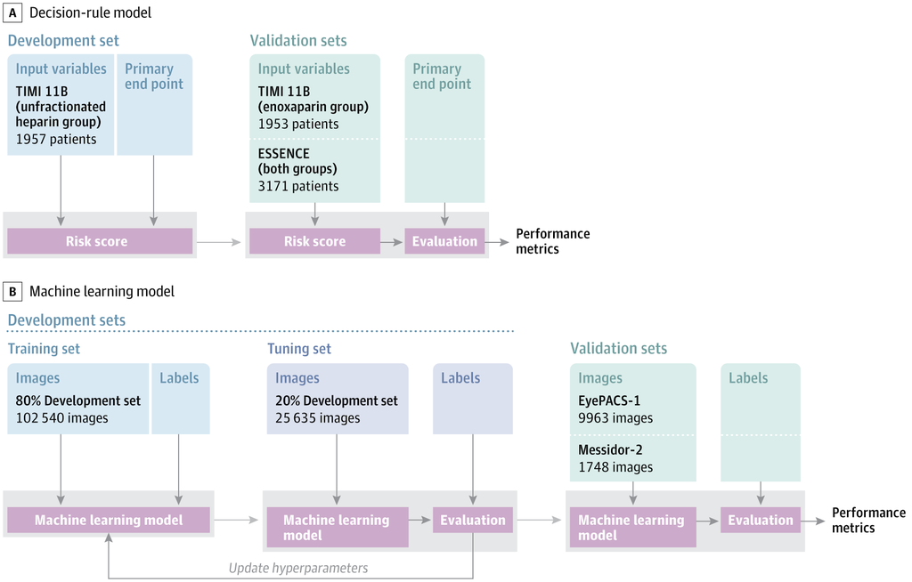

[圖片來源](https://jamanetwork.com/journals/jama/fullarticle/2754798)

在所謂的“非”機器學習模型(圖上半部)，通常可分訓練組與測試組，在作者定義為Development set和Validation set，重要的概念是訓練模型時，一定要記得先把測試組資料分出來，不可以用到這部分資料來訓練模型，最後才能得到真實的預測結果 (完全沒偷看答案的意思)。

在圖下半部，作者將此法命名為**3-step process**，主要差異是在訓練模型時多了一組**參數調整資料集**，原因是因為在多種機器學習模型中，有可調整的參數，在圖中稱為Hyperparameters，為了讓調整效果更好，會將訓練組再切分成小組，用來決定**最佳參數**，決定好以後，才用所有訓練組資料搭配最佳參數訓練模型，最後再用測試組做測試。

以下用邏輯迴歸歸Logistic Regression示範此圖上半部**不調參數**的作法，以及用隨機森林Random Forest示範此圖下半部**需要調整參數**的作法。

# 訓練組、測試組資料分割

不管要不要調參數，都需要分割訓練組與測試組，因此在進入兩個範例前，先將訓練組與測試組切好。

用`initial_split()`函數將資料分成訓練組與測試組，第一個參數放資料，第二個參數`prop`放訓練組測試組比例，第三個參數`strata`放分組抽樣依據。需要設定分組抽樣依據是因為若是整批資料隨機抽樣，很有可能在測試組或是訓練組會少一整個組別的資料(剛好都沒抽到的意思)，所以就分組，個別抽某個比例的人當訓練組，剩下的就當測試組。切割完後，用`training()`和`testing()`函數將訓練組測試組正式分開。

這邊要特別注意的是，因為`initial_split()`函數有隨機的概念，為了讓每次的實驗結果相同，我們會在有隨機事件前設定seed，作為隨機的依據，讓隨機每次都一樣，才不會每次跑都是不一樣的結果，這樣就無法產生可重複的實驗結果。

```r
set.seed(123)
splits<- initial_split(PimaIndiansDiabetes2,
                       prop=(3/4),
                       strata = diabetes)
DM_train<- training(splits)
DM_test<- testing(splits)
```

分組完後，查看訓練組的生病比例

```r
DM_train %>%
  count(diabetes) %>%
  mutate(prop = n/sum(n))
```

```
## # A tibble: 2 x 3
##   diabetes     n  prop
##   <fct>    <int> <dbl>
## 1 neg        197 0.668
## 2 pos         98 0.332
```

查看測試組的生病比例

```r
DM_test %>%
  count(diabetes) %>%
  mutate(prop = n/sum(n))
```

```
## # A tibble: 2 x 3
##   diabetes     n  prop
##   <fct>    <int> <dbl>
## 1 neg         65 0.670
## 2 pos         32 0.330
```

# 建立資料前處理“食譜”

資料前處理也是建立兩種模型都必須經歷的方法，因此提到最前方說明，前處理有很多方法，包括將類別變項轉為虛擬變項(dummy variables)，數值變項取log，數值變項正規化，以及日期資料處理等。

首先使用`recipe()`函數，設定模型訓練公式`diabetes ~ .`以及訓練用資料`DM_train`，要注意這邊只能用**訓練組資料**，不能用全部的資料。公式的意思是用`~`前方的`diabetes`當成outcome (想要預測的值)，`~`後方的`.`代表其他所有剩下的欄位都當成predictors (又稱variables 或是 features，為預測基礎)。

完成模型公式與資料設定後，就開始逐一加上想要做的資料前處理方法，在這邊列舉幾項我認為以此案例可能需要做的前處理

- `step_naomit(everything(), skip = TRUE)` 如果沒有在一開始將NA資料刪掉，通常要去除NA值
- `step_rose(diabetes)` 其實這個資料有病沒病的人沒差太多，只是呈現一下可以在此步驟設定oversampleing或是undersampling，這邊是指使用ROSE作為oversampling的演算法
- `step_dummy(all_nominal(), -all_outcomes())` 將所有的類別變項轉成虛擬變項，除了Outcome以外
- `step_zv(all_predictors())` 若有變項都是一樣的值，刪掉。舉例來說，若是整個資料都是女性，那性別欄位就不用拿來當作features了
- `step_normalize(all_predictors())` 將所有數值變項正規化

還有很多其他的前處理方法，可以參考`recipe()`函數的[說明文件](https://recipes.tidymodels.org/reference/recipe.html)

```r
gen_recipe <-
  recipe(diabetes ~ ., data = DM_train) %>%
  step_dummy(all_nominal(), -all_outcomes()) %>%
  step_zv(all_predictors()) %>%
  step_normalize(all_predictors())
summary(gen_recipe)
```

```
## # A tibble: 9 x 4
##   variable type    role      source
##   <chr>    <chr>   <chr>     <chr>
## 1 pregnant numeric predictor original
## 2 glucose  numeric predictor original
## 3 pressure numeric predictor original
## 4 triceps  numeric predictor original
## 5 insulin  numeric predictor original
## 6 mass     numeric predictor original
## 7 pedigree numeric predictor original
## 8 age      numeric predictor original
## 9 diabetes nominal outcome   original
```

# 邏輯迴歸Logistic Regression模型建立與效能評估範例

## Step 1 設定用邏輯迴建立模型

這邊以邏輯迴歸為例，用`logistic_reg()`函數與`set_engine("glm")`設定模型建立演算法為邏輯迴歸

```r
lr_mod <-
  logistic_reg() %>%
  set_engine("glm")
```

## Step 2 設定建模流程workflow

workflow將建模 (model)與資料前處理方法 (recipe)串成單一工作流程workflow

```r
lr_wflow <-
  workflow() %>%
  add_model(lr_mod) %>%
  add_recipe(gen_recipe)
lr_wflow
```

```
## == Workflow ======================================
## Preprocessor: Recipe
## Model: logistic_reg()
##
## -- Preprocessor ----------------------------------
## 3 Recipe Steps
##
## * step_dummy()
## * step_zv()
## * step_normalize()
##
## -- Model -----------------------------------------
## Logistic Regression Model Specification (classification)
##
## Computational engine: glm
```

## Step 3 訓練模型

使用剛剛串起來的工作流程，加上`fit()`函數，完成建模，並用`pull_workflow_fit()`與`tidy()`呈現建模結果，注意這裡也是只能用**訓練組資料**`DM_train`

```r
lr_fit <-
  lr_wflow %>%
  fit(data=DM_train)

lr_fit %>%
  pull_workflow_fit() %>%
  tidy()
```

```
## # A tibble: 9 x 5
##   term        estimate std.error statistic       p.value
##   <chr>          <dbl>     <dbl>     <dbl>         <dbl>
## 1 (Intercept)  -0.940      0.158   -5.97   0.00000000244
## 2 pregnant      0.223      0.197    1.13   0.257
## 3 glucose       1.07       0.195    5.49   0.0000000405
## 4 pressure     -0.116      0.162   -0.715  0.474
## 5 triceps      -0.0127     0.202   -0.0629 0.950
## 6 insulin      -0.0926     0.175   -0.530  0.596
## 7 mass          0.500      0.211    2.37   0.0179
## 8 pedigree      0.309      0.166    1.86   0.0631
## 9 age           0.392      0.208    1.88   0.0601
```

## Step 4 使用模型與測試組資料驗證模型效能

使用`predict()`函數，用剛剛訓練出來的模型`lr_fit`以及一開始分出的測試組`DM_test`產生預測結果，注意這邊要用測試組資料

```r
lr_pred <- lr_fit %>%
  predict(DM_test)
lr_pred
```

```
## # A tibble: 97 x 1
##    .pred_class
##    <fct>
##  1 pos
##  2 neg
##  3 neg
##  4 pos
##  5 pos
##  6 pos
##  7 neg
##  8 neg
##  9 neg
## 10 neg
## # ... with 87 more rows
```

將預測結果與答案結合

```r
lr_pred <- lr_fit %>%
  predict(DM_test) %>%
  bind_cols(DM_test %>% select(diabetes))
lr_pred
```

```
## # A tibble: 97 x 2
##    .pred_class diabetes
##    <fct>       <fct>
##  1 pos         pos
##  2 neg         pos
##  3 neg         neg
##  4 pos         pos
##  5 pos         pos
##  6 pos         pos
##  7 neg         neg
##  8 neg         neg
##  9 neg         neg
## 10 neg         neg
## # ... with 87 more rows
```

使用`accuracy()`函數，輸入預測結果與真實答案計算正確率

```r
lr_pred %>%
  accuracy(truth = diabetes,
          .pred_class)
```

```
## # A tibble: 1 x 3
##   .metric  .estimator .estimate
##   <chr>    <chr>          <dbl>
## 1 accuracy binary         0.814
```

但很多時候我們需要Area under the ROC curve，此時我們需要的不是直接pos或neg的結果，我們需要的是連續性的預測數值，這邊可將`predict()`函數的`type`參數設定為prob，即回傳各組預測值

```r
lr_pred <- lr_fit %>%
  predict(DM_test,
          type = "prob")%>%
  bind_cols(DM_test %>% select(diabetes))
lr_pred
```

```
## # A tibble: 97 x 3
##    .pred_neg .pred_pos diabetes
##        <dbl>     <dbl> <fct>
##  1    0.180     0.820  pos
##  2    0.648     0.352  pos
##  3    0.850     0.150  neg
##  4    0.0683    0.932  pos
##  5    0.125     0.875  pos
##  6    0.126     0.874  pos
##  7    0.854     0.146  neg
##  8    0.963     0.0366 neg
##  9    0.824     0.176  neg
## 10    0.733     0.267  neg
## # ... with 87 more rows
```

得到各組預測值後，可用`roc_curve()`畫ROC curve

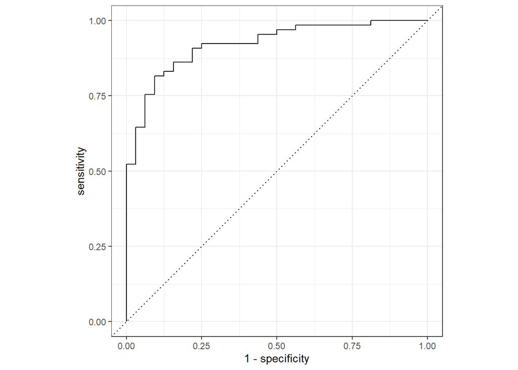

```r
lr_pred %>%
  roc_curve(truth = diabetes,
            .pred_pos) %>%
  autoplot()
```

當然也能用`roc_auc()`算Area under the ROC curve

```r
lr_pred %>%
  roc_auc(truth = diabetes,
          .pred_pos)
```

```
## # A tibble: 1 x 3
##   .metric .estimator .estimate
##   <chr>   <chr>          <dbl>
## 1 roc_auc binary         0.921
```

以上就是使用邏輯迴歸建立模型與效能測試流程，可以發現完全沒有調整任何參數，因基本邏輯迴歸不用調參數。

# 隨機森林Random Forest模型建立、參數調整與效能評估範例

## Step 1 設定平行處理

因為模型參數調整需要一直不斷建立模型與測試，所以設定平行處理會快一些，`tidymodels`套組支援平行處理，細節可參考[官方文件](https://tune.tidymodels.org/articles/extras/optimizations.html)

```r
all_cores <- parallel::detectCores(logical = FALSE)
library(doParallel)
cl <- makePSOCKcluster(all_cores)
registerDoParallel(cl)
```

## Step 2 設定用隨機森林建立模型以及要調整的參數

這邊以隨機森林為例，用`rand_forest()`函數與`set_engine("ranger")`設定模型建立演算法為基於`ranger`套件的隨機森林演算法，因為隨機森林有迴歸版與分類版，因此使用`set_mode("classification")`設定我們要用分類演算法。

在隨機森林`rand_forest()`函數中，可設定幾個參數，說明如下:

- mtry: 在切割節點時，隨機抽取n個特徵，並從中選最適合的特徵當作節點
- min_n: 每個節點的最小資料數，如果設為10，當該節點的資料剩十筆或更少時，就不會再切割
- trees: 建模要用幾棵樹

在這個範例中，我將要建幾棵樹設定為1000，其他兩個參數則是想用交叉驗證法(Cross Validation)來調整，因此將想調的參數值設為`tune()`，表示這些參數要調，不想在現階段指定。

```r
rf_mod <-
  rand_forest(mtry = tune(), min_n = tune(),
              trees = 1000) %>%
  set_engine("ranger") %>%
  set_mode("classification")

rf_mod
```

```
## Random Forest Model Specification (classification)
##
## Main Arguments:
##   mtry = tune()
##   trees = 1000
##   min_n = tune()
##
## Computational engine: ranger
```

## Step 3 設定建模流程workflow

建模流程同邏輯迴歸，將模型與資料前處理方法串接成一個工作流程

```r
rf_wflow <- workflow() %>%
  add_model(rf_mod) %>%
  add_recipe(gen_recipe)
```

## Step 4 參數調整組資料分割

剛剛有提到我想要調整的參數為mtry以及min_n，調整的方法為交叉驗證法(Cross Validation)，這邊用`tidymodels`官網的圖來說明架構

[figure not shown]

[圖片來源](https://www.tidymodels.org/start/resampling/)

在圖中，首先將所有資料分成測試組訓練組，也就是本篇文章一開始做的切割，為了調整參數，我們會再切訓練組的資料，做為測試各參數效能的**調整訓練**以及**調整測試**。

切割**參數調整組**有很多種方法，可以用**bootstrap**法隨機抽，也可使用這邊的**交叉驗證**範例，交叉驗證的概念如下圖的下半部

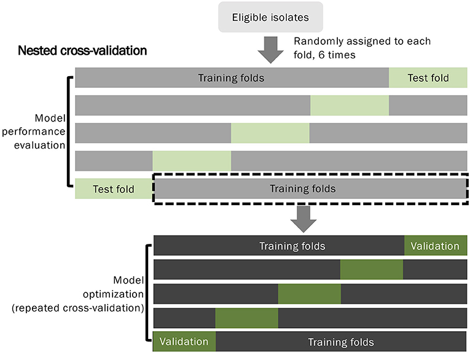

[圖片來源](https://doi.org/10.3389/fmicb.2018.02393)

圖片下半部為5-fold Cross Validation的示意圖，可以看到每份資料都會被拿來當作**調整訓練**以及**調整測試**組，經過幾次測試後，用**調整測試**組的效能來決定一組最佳參數。

這邊我們使用10-fold Cross Validation為例，先用`vfold_cv()`函數，設定分割基準為**訓練組**，要分10份`v=10`，分割時一樣要注意糖尿病的比例不能差太多

```r
set.seed(345)
folds <- vfold_cv(DM_train, v = 10,
                  strata = diabetes)
folds
```

```
## #  10-fold cross-validation using stratification
## # A tibble: 10 x 2
##    splits           id
##    <named list>     <chr>
##  1 <split [265/30]> Fold01
##  2 <split [265/30]> Fold02
##  3 <split [265/30]> Fold03
##  4 <split [265/30]> Fold04
##  5 <split [265/30]> Fold05
##  6 <split [265/30]> Fold06
##  7 <split [265/30]> Fold07
##  8 <split [266/29]> Fold08
##  9 <split [267/28]> Fold09
## 10 <split [267/28]> Fold10
```

## Step 5 調整參數

完成分割後，可將之前的建模流程串接至`tune_grid()`函數，這個函數可以設定參數調整的方法，首先是調整要用的**參數調整組資料**`resamples = folds`，要測試幾組參數`grid = 50`，測試時要用什麼效能評估方式，這邊設定為Area under the ROC curve `metrics = metric_set(roc_auc)`。因為要重複訓練測試多次，因此這程式碼執行會需要一些時間。

```r
rf_res <-
  rf_wflow %>%
  tune_grid(
    resamples = folds,
    grid = 50,
    metrics = metric_set(roc_auc),
    control=control_resamples(save_pred = TRUE)
    )
```

執行完後，可用`collect_metrics()`查看各參數效能

```r
rf_res %>%
  collect_metrics()
```

```
## # A tibble: 49 x 7
##     mtry min_n .metric .estimator  mean     n std_err
##    <int> <int> <chr>   <chr>      <dbl> <int>   <dbl>
##  1     1     5 roc_auc binary     0.796    10  0.0248
##  2     1    15 roc_auc binary     0.808    10  0.0244
##  3     1    27 roc_auc binary     0.808    10  0.0260
##  4     2    11 roc_auc binary     0.800    10  0.0234
##  5     2    21 roc_auc binary     0.809    10  0.0247
##  6     2    23 roc_auc binary     0.809    10  0.0230
##  7     2    29 roc_auc binary     0.811    10  0.0241
##  8     2    32 roc_auc binary     0.813    10  0.0238
##  9     2    35 roc_auc binary     0.811    10  0.0243
## 10     2    36 roc_auc binary     0.814    10  0.0224
## # ... with 39 more rows
```

也可畫個圖呈現參數調整對效能的影響，由圖可知在這個範例中min_n越大效能越好

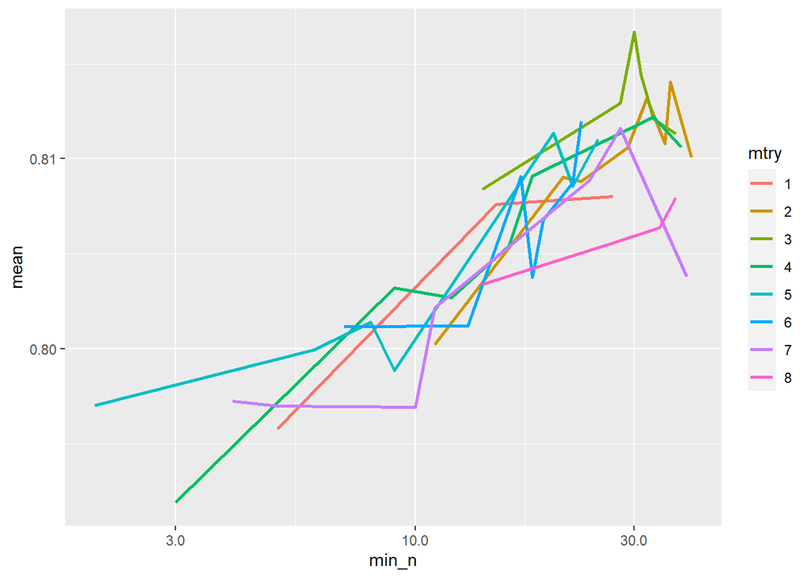

```r
rf_res %>%
  collect_metrics() %>%
  mutate(mtry = factor(mtry)) %>%
  ggplot(aes(min_n, mean, color = mtry)) +
  geom_line(size=1) +
  scale_x_log10(labels = scales::label_number())
```

搭配`show_best()`函數可呈現Area under the ROC curve最優的幾組參數

```r
rf_res %>%
  show_best("roc_auc")
```

```
## # A tibble: 5 x 7
##    mtry min_n .metric .estimator  mean     n std_err
##   <int> <int> <chr>   <chr>      <dbl> <int>   <dbl>
## 1     3    30 roc_auc binary     0.817    10  0.0218
## 2     3    31 roc_auc binary     0.814    10  0.0232
## 3     2    36 roc_auc binary     0.814    10  0.0224
## 4     2    32 roc_auc binary     0.813    10  0.0238
## 5     3    28 roc_auc binary     0.813    10  0.0231
```

## Step 6 使用最佳參數與訓練組資料建立最終模型

在完成參數調整後，我們會使用最佳參數(意即Area under the ROC curve最高的一組參數)來建立最終模型，用`select_best()`函數可選出最好的一組參數`best_rf`

```r
best_rf <- rf_res %>%
  select_best("roc_auc")
best_rf
```

```
## # A tibble: 1 x 2
##    mtry min_n
##   <int> <int>
## 1     3    30
```

為了將參數節合至原有的建模流程，可用`finalize_workflow()`函數輸入剛剛選出的最佳參數`best_rf`，建立一個**最終建模流程**

```r
final_wflow <-
  rf_wflow %>%
  finalize_workflow(best_rf)

final_wflow
```

```
## == Workflow ======================================
## Preprocessor: Recipe
## Model: rand_forest()
##
## -- Preprocessor ----------------------------------
## 3 Recipe Steps
##
## * step_dummy()
## * step_zv()
## * step_normalize()
##
## -- Model -----------------------------------------
## Random Forest Model Specification (classification)
##
## Main Arguments:
##   mtry = 3
##   trees = 1000
##   min_n = 30
##
## Computational engine: ranger
```

**最終建模流程**建立後，即可用`fit()`建模，注意這邊用的是完整的訓練資料`DM_train`

```r
final_rf_model <-
  final_wflow %>%
  fit(data = DM_train)

final_rf_model
```

```
## == Workflow [trained] ============================
## Preprocessor: Recipe
## Model: rand_forest()
##
## -- Preprocessor ----------------------------------
## 3 Recipe Steps
##
## * step_dummy()
## * step_zv()
## * step_normalize()
##
## -- Model -----------------------------------------
## Ranger result
##
## Call:
##  ranger::ranger(formula = formula, data = data, mtry = ~3L, num.trees = ~1000,      min.node.size = ~30L, num.threads = 1, verbose = FALSE, seed = sample.int(10^5,          1), probability = TRUE)
##
## Type:                             Probability estimation
## Number of trees:                  1000
## Sample size:                      295
## Number of independent variables:  8
## Mtry:                             3
## Target node size:                 30
## Variable importance mode:         none
## Splitrule:                        gini
## OOB prediction error (Brier s.):  0.1559871
```

## Step 7 用測試組資料驗證最終模型效能

使用`predict()`函數，用剛剛訓練出來的模型`final_rf_model`以及一開始分出的測試組`DM_test`產生預測結果，注意這邊要用測試組資料

```r
rf_pred <- final_rf_model %>%
  predict(DM_test)
rf_pred
```

```
## # A tibble: 97 x 1
##    .pred_class
##    <fct>
##  1 pos
##  2 neg
##  3 neg
##  4 pos
##  5 pos
##  6 pos
##  7 neg
##  8 neg
##  9 neg
## 10 neg
## # ... with 87 more rows
```

將預測結果與答案結合

```r
rf_pred <- final_rf_model %>%
  predict(DM_test) %>%
  bind_cols(DM_test %>% select(diabetes))
rf_pred
```

```
## # A tibble: 97 x 2
##    .pred_class diabetes
##    <fct>       <fct>
##  1 pos         pos
##  2 neg         pos
##  3 neg         neg
##  4 pos         pos
##  5 pos         pos
##  6 pos         pos
##  7 neg         neg
##  8 neg         neg
##  9 neg         neg
## 10 neg         neg
## # ... with 87 more rows
```

使用預測結果與真實答案計算正確率

```r
rf_pred %>%
  accuracy(truth = diabetes,
          .pred_class)
```

```
## # A tibble: 1 x 3
##   .metric  .estimator .estimate
##   <chr>    <chr>          <dbl>
## 1 accuracy binary         0.804
```

但很多時候我們需要Area under the ROC curve，此時我們需要的不是直接pos或neg的結果，我們需要的是連續性的預測數值，這邊可將`predict()`函數的`type`參數設定為prob，即回傳各組預測值

```r
rf_pred <- final_rf_model %>%
  predict(DM_test,
          type = "prob")%>%
  bind_cols(DM_test %>% select(diabetes))
rf_pred
```

```
## # A tibble: 97 x 3
##    .pred_neg .pred_pos diabetes
##        <dbl>     <dbl> <fct>
##  1     0.370    0.630  pos
##  2     0.509    0.491  pos
##  3     0.655    0.345  neg
##  4     0.159    0.841  pos
##  5     0.104    0.896  pos
##  6     0.181    0.819  pos
##  7     0.864    0.136  neg
##  8     0.954    0.0464 neg
##  9     0.805    0.195  neg
## 10     0.628    0.372  neg
## # ... with 87 more rows
```

得到各組預測值後，可用`roc_curve()`畫ROC curve

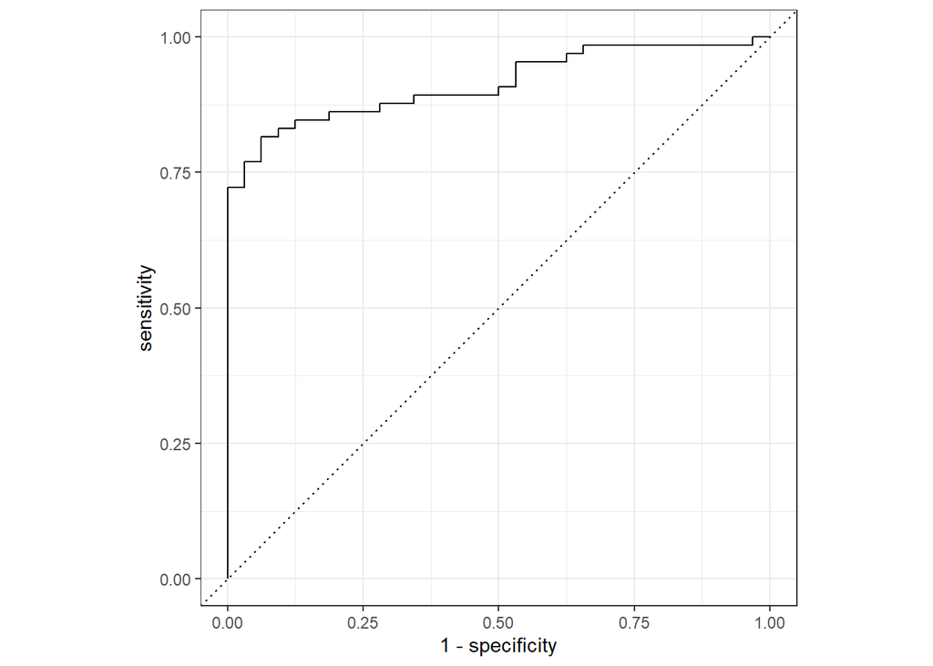

```r
rf_pred %>%
  roc_curve(truth = diabetes,
            .pred_pos) %>%
  autoplot()
```

當然也能用`roc_auc()`算Area under the ROC curve

```r
rf_pred %>%
  roc_auc(truth = diabetes,
          .pred_pos)
```

```
## # A tibble: 1 x 3
##   .metric .estimator .estimate
##   <chr>   <chr>          <dbl>
## 1 roc_auc binary         0.913
```

以上就是使用隨機森林建立模型、調整參數以及與效能測試流程，多了使用交叉驗證法調整參數的步驟。